# Hernandez_Gabriel_HW2

Gabriel Hernandez

15 September 2023

```r
install.packages('tidyverse')
install.packages('tidycensus')
install.packages('sf')
install.packages('kableExtra')
install.packages("dplyr")
install.packages("viridis")
install.packages("shades")
```

# Introduction

Cities can draw investment through the advancement of transit-oriented development (TOD) opportunities. At a time when the narrative is that cities do not generate enough revenue to perform better for their constituents, TOD presents an opportunity to raise property values and property tax collections. A fundamental question must be answered to advocate for more TOD: do people pay to be near transit stations? Our team studied the Metrorail network in the city of Washington, District of Columbia (DC) and census tract data to answer this question. Furthermore we hope that this study provides insight into some of the dynamics surrounding investment, TOD, and DC.

### A Note on Selection

The ACS 5-Year Estimates data was collected for both 2009 and 2017. In our methods we defined a TOD census tract as one whose geographical center is within a half mile of a train station. This is a conservative approach that disqualifies some census tracts that are relatively near to the station but that do not meet the criteria. Alternatives to our selection would could select more tracts as TOD, which could dilute the contrasts, if any, in the data. We chose a half-mile distance based on the idea that people that want to live near TOD do not want to talk more than 10 minutes to get to it.

[output not shown]

## View of Metro Stations & Lines

The Washington Metro is the second-busiest heavy rail rapid transit system in the US. The visible core of the Metrorail system radiates its lines towards the surrounding area. If people are willing to invest in TOD, we will see higher populations and median rents near transit stations. Given that many individual lines connect in the core area, we would to have higher numbers there than in the rest of the system.

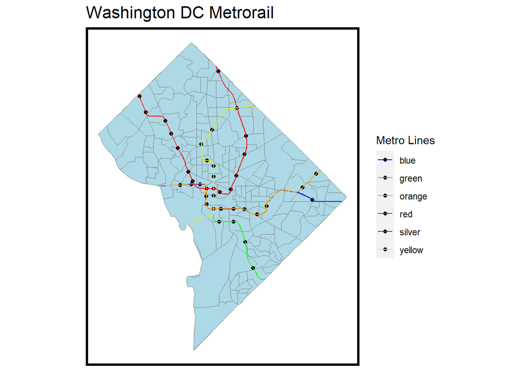

```r
ggplot() +
  geom_sf(data=allTracts,
          fill="lightblue",
          color="gray50")+
  geom_sf(data=metroStops,
          show.legend = "point", size=1.5,
          color = "black")+ # str_split(LINE,",",simplify=T)[1]) maybe (too many legend entries)
  geom_sf(data=metroLines,
          aes(colour=NAME))+
  geom_line(linewidth=100)+
  scale_colour_manual(values=c("blue","green","orange","red","gray30","yellow2"))+
  labs(color="Metro Lines",
       title="Washington DC Metrorail")+
  mapTheme()
```

# Results - Distance from Station and Mean of Median Rent

## Does Proximity Matter?

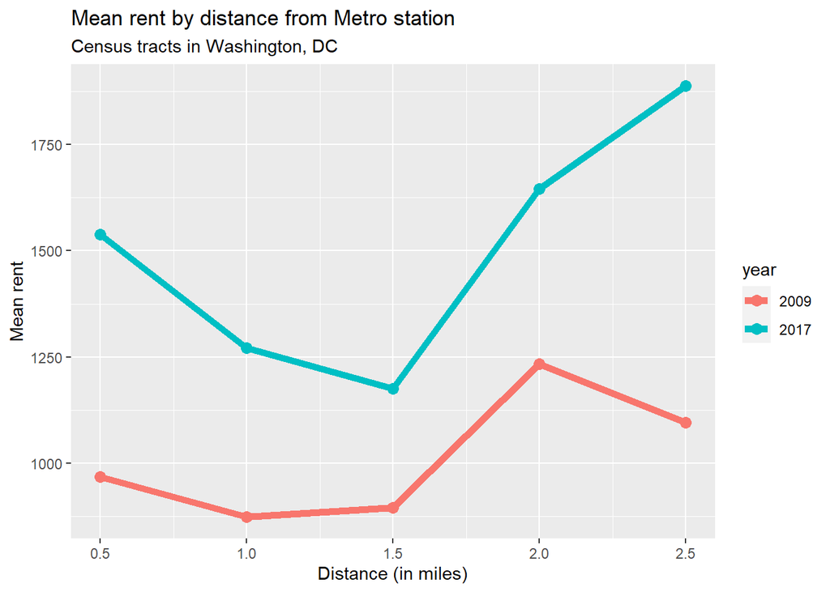

```r
allTracts.rings <-
  allTracts %>%
  select(GEOID, year) %>%
  st_centroid() %>%
  st_join(DCmetro_MRB, join = st_intersects) %>%
  st_drop_geometry() %>%
  left_join(dplyr::select(allTracts, GEOID, MedRent, year),
            by=c("GEOID"="GEOID", "year"="year")) %>%
  st_sf() %>%
  mutate(distance = distance / 5280) #convert to miles

allTracts.rings.summary <- st_drop_geometry(allTracts.rings) %>%
    group_by(distance, year) %>%
    summarize(Mean_Rent = mean(MedRent, na.rm=T))

ggplot(allTracts.rings.summary,
       aes(distance, Mean_Rent, colour=year)) +
      geom_point(size=3) +
      geom_line(size=2) +
      labs(
        title="Mean rent by distance from Metro station",
        subtitle="Census tracts in Washington, DC",
        x="Distance (in miles)",
        y="Mean rent")
```

The line plot above shows an interesting relationship between distance from stations and the Mean of Rents for census tracts that are within a multiple-ring buffer around Train Stations.

There is a clear decline in mean rent as you get further from a station, indicating that people will pay a premium in rent to be close to the station. However, the line also shows that after 1.5 miles from the station mean rents rise. This could be due to many reasons, but it suggests that the areas 1.5 miles from stations have unique characteristics that people are willing to pay a premium for. It is possible that in a walkable city, at 1.5 miles from a station, it makes more sense to have a vehicle. Reflecting powers of mobility, people with cars in DC also own more expensive properties and are willing to pay higher rents. It would be interesting to compare housing stock characteristics to see if developmental history influences what is observed in this plot.

# Dot Density - 2009/2017 Population and Rent per Metro Station

The following maps show changes in population and rent in tracts within a half mile radius of Metro stations.

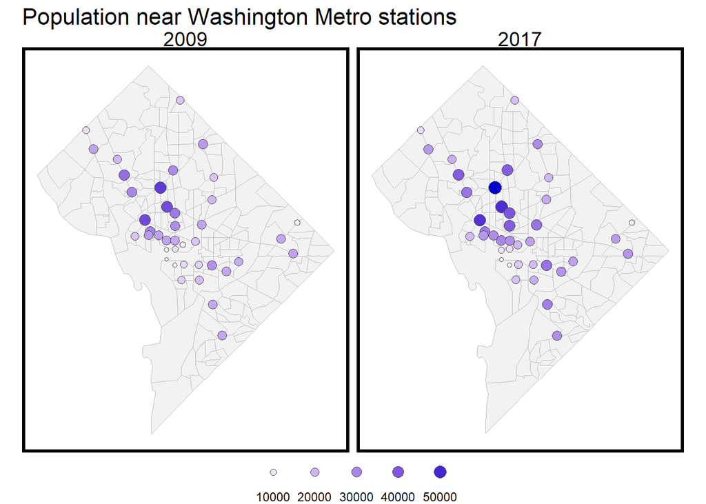

```r
library(dplyr)
library(sf)
library(ggplot2)
library(viridis)

selection1 <-
  allTracts.group[buffer,] %>%
  dplyr::select(TotalPop,MedRent,year) %>%
  mutate(Selection_Type = "Spatial Selection")

stopBuffer <- st_buffer(metroStops, 2640)
stopBuffer$ID <- seq_along(stopBuffer$geometry)

TOD_tracts <- selection1 %>%
  st_intersection(stopBuffer, selection1)

pop_rent09 <- TOD_tracts %>%
  st_drop_geometry() %>%
  group_by(ID,year) %>%
  summarize(x = mean(MedRent, na.rm = T), y = sum(TotalPop, na.rm = T))

symbol_pos <- stopBuffer %>%
  dplyr::select(ID) %>%
  st_centroid()


# Bubble choropleth maps

labels_y <- symbol_pos %>%
  left_join(pop_rent09,
            by = c("ID" = "ID")) %>%
  arrange(desc(y))

ggplot() + #try to split these into discrete var
  geom_sf(data = allTracts.group,
          fill = "gray95",
          color = "gray") +
  geom_sf(data = labels_y,
          aes(size = y,
              fill = y),#ask ed discussion why this isnt combining
          pch = 21,
          col = "gray30") +
  scale_size(
    range = c(1, 4),
    guide = guide_legend(
      direction = "horizontal",
      nrow = 1,
      label.position = "bottom")) +
  guides(fill = guide_legend(title = "")) +
  scale_fill_gradient(low = "white", high = "blue3") +
  labs(title = "Population near Washington Metro stations",
       sub = "Based on 1/2 mile buffers",
       size = "") +
  theme_void() +
  facet_wrap(~year) +
  mapTheme()+
  theme(legend.position = "bottom")
```

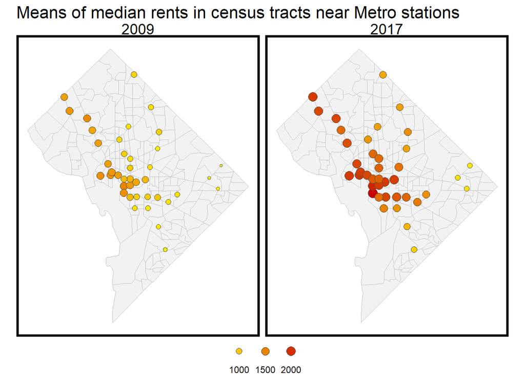

```r
labels_x <- symbol_pos %>%
  left_join(pop_rent09,
            by = c("ID" = "ID")) %>%
  arrange(desc(x))

ggplot() +
  geom_sf(data = allTracts.group,
          fill = "gray95",
          color = "gray") +
  geom_sf(data = labels_x,
          pch = 21,
          aes(size = x,
              fill = x),
          col = "gray30") +
  scale_size(
    range = c(1, 4),
    guide = guide_legend(
      direction = "horizontal",
      nrow = 1,
      label.position = "bottom")) +
  guides(fill = guide_legend(title = "")) +
  scale_fill_gradient(low = "yellow", high = "red3") +
  labs(title = "Means of median rents in census tracts near Metro stations",
       sub = "Based on 1/2 mile buffers",
       size = "") +
  theme_void() +
  facet_wrap(~year) +
  mapTheme() +
  theme(legend.position = "bottom")
```

The graduated symbols above highlight a couple of things. Population has certainly increased between 2009 and 2017, but the size of the differences do not compare to what is seen with the Mean of Median rents. This suggests that population growth is not strongly related to the rise in rents near transit stations. Rises in rent may reflect low supply of TOD units and/or a high demand for them, indicating that people are looking to pay to live in the TOD areas of the city.

## Visualizing indicators across time and space

To investigate further, I chose these four indicators for further analysis: Percent Foreign Born (out of total household population), Percent Poverty (out of total household population), Percent Vacant (out of total household units), and the percentage of all commuters in a tract that commute less than 30 minutes to get to work. The following bar plots and chloropleth maps visualize my indicators across space and time.

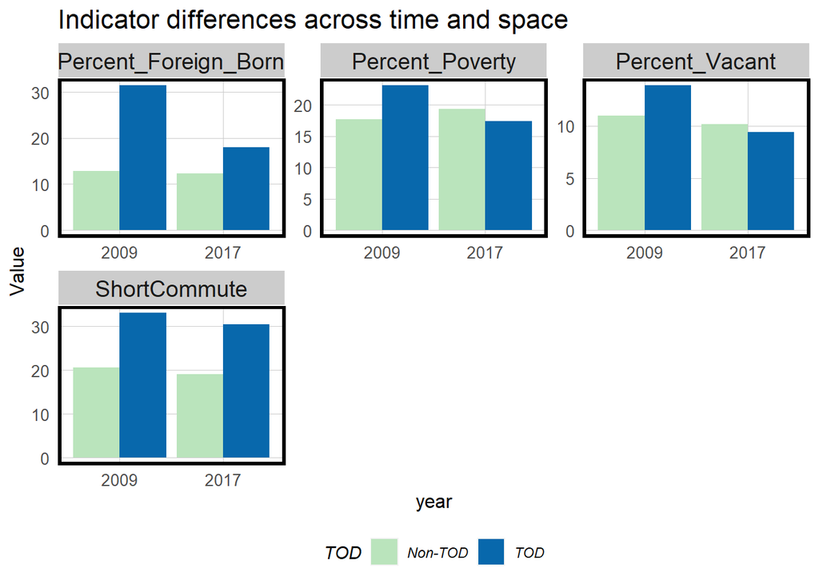

```r
allTracts.Summary <-
  st_drop_geometry(allTracts.group) %>%
    group_by(year, TOD) %>%
    summarize(CRent = mean(MedRent, na.rm = T),
              Population = mean(TotalPop, na.rm = T),
              ShortCommute = mean(pctPubTrans_LT30, na.rm = T),
              MedTT = mean(pctPubTrans_30To59*100, na.rm = T),
              LongCommute = mean(pctPubTrans_HourUp*100, na.rm = T),
              HH_Count = mean(TotalHHs,na.rm=T),
              GRent = mean(MedGrossRent,na.rm=T),
              RentPorIncome = mean(RentPortionOfInc,na.rm=T),
              Percent_Poverty = mean(pctPoverty,na.rm=T),
              Percent_Foreign_Born = mean(pctForeignBorn,na.rm=T),
              Percent_Vacant = mean(pctVacant,na.rm=T))%>%
dplyr::select("TOD","Percent_Vacant","ShortCommute","Percent_Poverty","Percent_Foreign_Born")




allTracts.Summary %>%
  gather(Variable, Value, -year, -TOD) %>%
  ggplot(aes(year, Value, fill = TOD)) +
  geom_bar(stat = "identity", position = "dodge") +
  facet_wrap(~Variable, scales = "free", ncol=3) +
  scale_fill_manual(values = c("#bae4bc", "#0868ac")) +
  labs(title = "Indicator differences across time and space") +
  plotTheme() + theme(legend.position="bottom")
```

```r
view(allTracts.Summary)

kable(allTracts.Summary, digits=2)%>%
  kable_styling() %>%
  footnote(general_title = "\n",
           general = "Table 1.2")
```

| year | TOD | Percent_Vacant | ShortCommute | Percent_Poverty | Percent_Foreign_Born |
| --- | --- | --- | --- | --- | --- |
| 2009 | Non-TOD | 10.98 | 20.63 | 17.71 | 12.80 |
| 2009 | TOD | 13.92 | 33.08 | 23.15 | 31.51 |
| 2017 | Non-TOD | 10.16 | 19.09 | 19.36 | 12.33 |
| 2017 | TOD | 9.39 | 30.38 | 17.38 | 18.01 |

Table 1.2

I chose indicators with Non-TOD tract data that had two important qualities: they needed to show little to no change between 2009 and 2017 and deviate from values in TOD tracts.

Along with the rises in rents in that we saw earlier, between 2009 and 2017 TOD tracts also reduced the poverty rate and the percent of vacant units. Both of these changes reflect investment taking place near transit station. On the other hand, the percent of vacant units barely decreased, and the percent of poverty actually increased in Non-TOD areas. This raises questions about who is investment serving and how are its fiscal benefits being distributed.

The data also points to a possible uprooting or displacement of foreign born populations near TOD that could be long-term residents of the neighborhood. If there is a dynamic of displacement, what is happening to the commercial real estate in the area? Are there new businesses?

Lastly, I would like to note the short commute indicator. Residing in a TOD tract increases one’s power of mobility and that is reflected in the values of commute time. People are willing to pay to be near transit stations in part because it decreases their time cost to work. That fact may drive the demand for TOD.

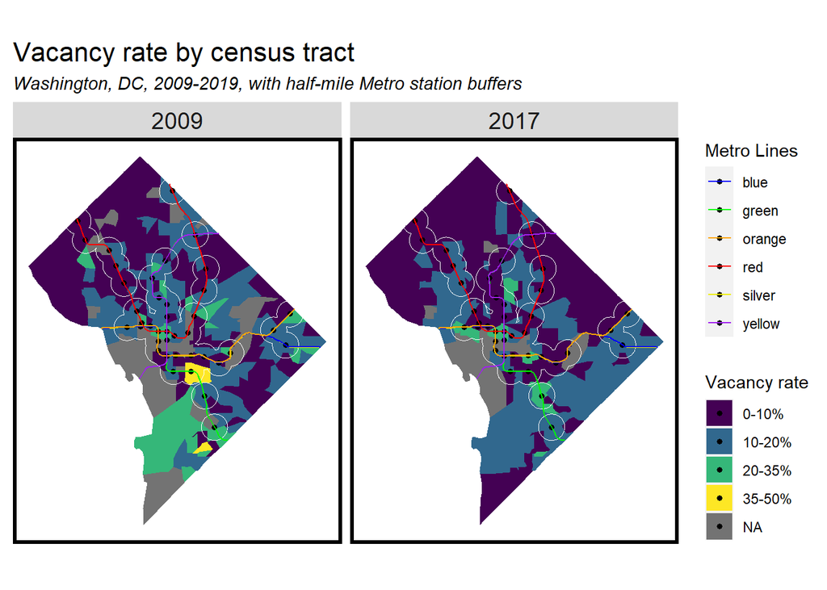

```r
labslist<- c("TOD","Percent_Vacant","ShortCommute","Percent_Poverty","Percent_Foreign_Born")
br <- c(0, 10, 20,35,50)

allTracts.group$pctVacantCat <- cut(allTracts.group$pctVacant,
                                         breaks = br,
                                         dig.lab = 5)

library(ggplot2)
library(dplyr)
library(sf)


 ggplot() +
  geom_sf(data=allTracts.group,
          aes(fill=pctVacantCat),
          color=NA)+
  geom_sf(data=metroStops,
          show.legend = "point", size=1.2,
          color = "black")+
  geom_sf(data=buffer,
          color="white",
          fill="transparent")+
  geom_sf(data=metroLines,
          aes(color=NAME))+
  geom_line(size=100)+
  scale_fill_viridis(discrete=T,
                     na.value="gray45",
                     labels=c("0-10%","10-20%","20-35%","35-50%","NA"))+
  scale_color_manual(values=c("blue","green","orange","red","yellow2","purple",NULL,NULL,NULL,NULL))+
  labs(color="Metro Lines",
       fill="Vacancy rate",
       title="Vacancy rate by census tract",
       subtitle="Washington, DC, 2009-2019, with half-mile Metro station buffers")+
  facet_wrap(~year)+
  mapTheme()
```

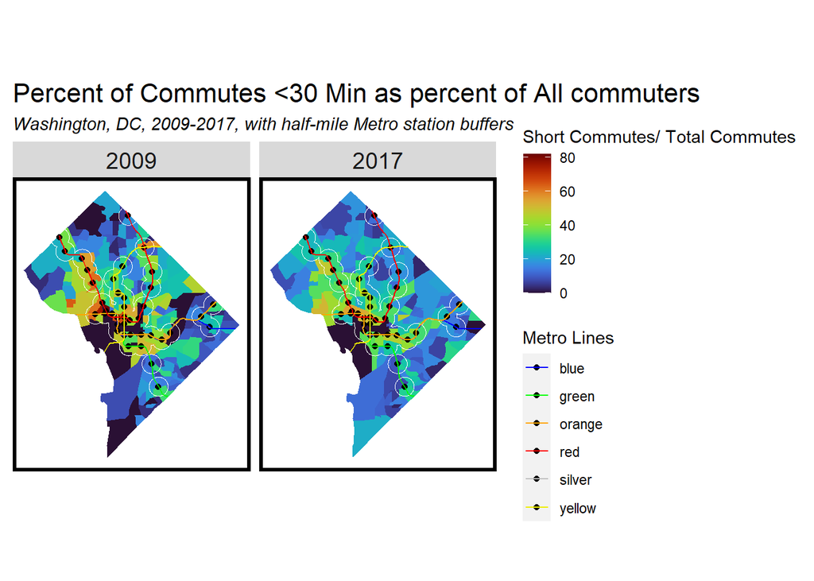

```r
library(viridis)
library(shades)

br_1 <- c(0, 10, 20,35,50)

allTracts.group$pctShortCommuteCut <- cut(allTracts.group$pctPubTrans_LT30,
                                         breaks = br,
                                         dig.lab = 5)

ggplot() +
  geom_sf(data=allTracts.group,
          aes(fill=pctPubTrans_LT30),
          color=NA)+
  geom_sf(data=metroStops,
          show.legend = "point", size=1.5,
          color = "black")+
  geom_sf(data=buffer,
          color="white",
          fill="transparent")+
  geom_sf(data=metroLines,
          aes(color=NAME))+
  geom_line(size=10)+
  scale_colour_manual(values=c("blue","green","orange","red","gray75","yellow2",NULL,NULL,NULL,NULL))+
  brightness(scale_fill_viridis(option="turbo"),scalefac(0.88))+
  labs(color="Metro Lines",
       fill="Short Commutes/ Total Commutes",
       title="Percent of Commutes <30 Min as percent of All commuters",
       subtitle="Washington, DC, 2009-2017, with half-mile Metro station buffers",
       caption="")+
  facet_wrap(~year)+
  mapTheme()
```

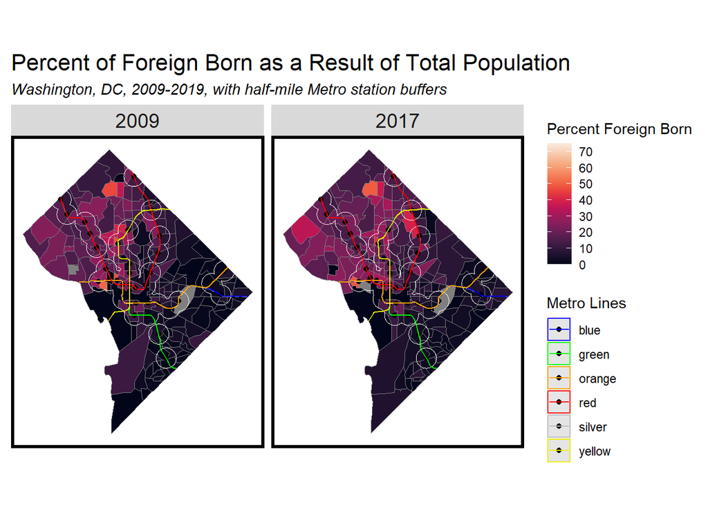

```r
ggplot() +
   geom_sf(data=allTracts.group,
           aes(fill=pctForeignBorn,
           color=NA)) +
   geom_sf(data=metroStops,
           show.legend = "point", size=1.5,
           color = "black") +
   geom_sf(data=buffer,
           color="white",
           fill="transparent") +
   geom_sf(data=metroLines,
           aes(color=NAME)) +
   geom_line(size=5) +
   scale_colour_manual(values=c("blue","green","orange","red","gray75","yellow2",NULL,NULL,NULL,NULL)) +
   scale_fill_viridis(option="rocket", limits=c(0, 75), breaks=seq(0, 75, by=10)) +  # Adjust the color scale
   labs(color="Metro Lines",
        fill="Percent Foreign Born",
        title="Percent of Foreign Born as a Result of Total Population",
        subtitle="Washington, DC, 2009-2019, with half-mile Metro station buffers") +
   facet_wrap(~year) +
   mapTheme()
```

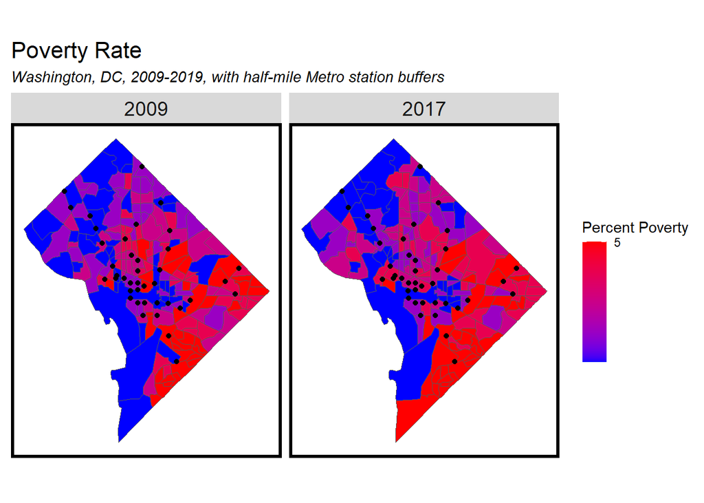

```r
ggplot() +
   geom_sf(data=allTracts.group,
          aes(fill = as.numeric(q5(pctPoverty)))) +  # Convert to numeric if necessary
   geom_sf(data=metroStops,
          show.legend = "point", size=1.5,
          color = "black") +
   # Other geoms and settings...
   scale_fill_continuous(
     low = "blue",            # Color for the lowest value
     high = "red",            # Color for the highest value
     breaks = c(5, 10, 30),   # Specify breaks if needed
     name = "Percent Poverty",  # Label for the legend
     na.value = "gray50"      # Color for missing (NA) values, if applicable
   ) +
   # Other scales and settings...
   labs(color="Metro Lines",
       title="Poverty Rate",
       fill="Percent Poverty",
       subtitle="Washington, DC, 2009-2019, with half-mile Metro station buffers") +
   facet_wrap(~year)+
  mapTheme()
```

# Conclusion and Suggestions

### People in the DC area are willing to pay for TOD.

The study highlights that there is a relationship between TOD areas a half-mile from stations and census tract data. Rents were visibly higher in the core and increased over time, highlight demand for TOD. The investment in TOD has led to a decrease in both poverty and vacant units but has also resulted in a large percentage of the foreign population leaving the area. This could be for many reasons but a further study should look deeper into the community and the title security of its families.

Based on the analysis, it can be concluded that people are willing to pay a premium to be in TOD areas. It may be because the neighborhoods have desirable characteristics, but our data shows that the difference in commute time to work really distinguishes TOD areas, with more people reporting commutes under 30 minutes. According to our data, access to the Metrorail is worth paying a premium in DC.